# Predicting the manner of exercise performance

### Prediction for the test dataset

Removing var or colunm with NA from test dataset:

```r
pml_testing <- pml_testing[, colSums(is.na(pml_testing)) == 0]
dim(pml_testing) # 20 obs. of  60 variables
```

```
## [1] 20 60
```

Removing var are not important from test dataset:

```r
test_remove <- grepl("^X|timestamp|window", names(pml_testing))
summary(test_remove) # 6 more var removed
```

```
##    Mode   FALSE    TRUE    NA's
## logical      54       6       0
```

```r
pml_testing <- pml_testing[, !test_remove]
dim(pml_testing) # 20 obs. of  54 variables
```

```
## [1] 20 54
```

```r
pml_testing_final <- pml_testing[, sapply(pml_testing, is.numeric)]
dim(pml_testing_final) # 20 obs and 53 variables
```

```
## [1] 20 53
```

To see all var names:

```r
names(pml_testing_final) # 53 variables
```

So there are the same 53 var or features while only 52 in traning dataset

Remove ‘problem_id’ var from the test dataset

```r
pml_testing_final <- pml_testing_final[, -53]
dim(pml_testing_final) # 52 var
```

```
## [1] 20 52
```

Now there are the same 52 var or features as in traning dataset

Using the fitted model to Predict for the orginal test dataset

```r
predict_test <- predict(rfmodFit, pml_testing_final)
predict_test
```

```
##  [1] B A B A A E D B A A B C B A E E A B B B
## Levels: A B C D E
```

## Visualization

#### Table 1: Prediction Results for validation data set

Tabulate results

```r
table(rf_predict,testing_data$classe)
```

```
##
## rf_predict    A    B    C    D    E
##          A 1393    8    0    0    0
##          B    2  938   15    0    1
##          C    0    3  838    9    3
##          D    0    0    2  793    2
##          E    0    0    0    2  895
```

#### Figure 1: Decision tree plot

Check overall correct results of prediction by the rf algorithm

```r
testing_data$predRight <- rf_predict==testing_data$classe
table(testing_data$predRight)
```

```
##
## FALSE  TRUE
##    47  4857
```

Decision tree plot

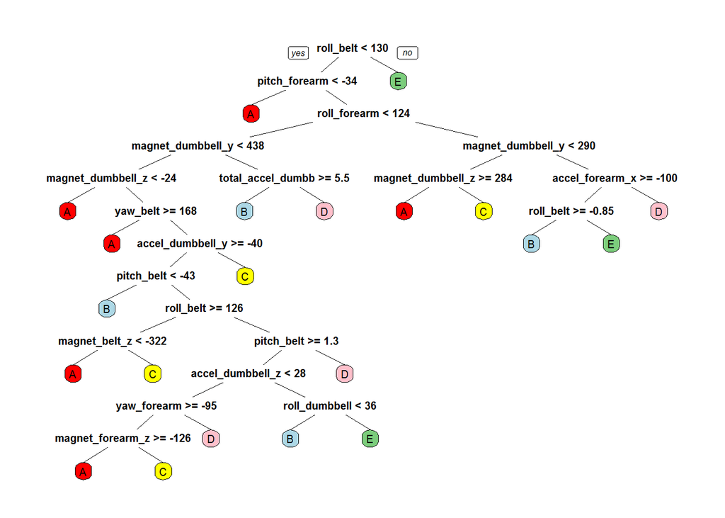

```r
library(rpart)
library(rpart.plot)
treeplot_model <- rpart(classe ~ ., data=training_data, method="class")
prp(treeplot_model,
    box.col=c("red", "lightblue", "yellow", "pink", "palegreen3")[treeplot_model$frame$yval])
```

## Creating files for Prediction Assignment Submission

```r
answers <- as.vector(predict_test)

pml_write_files = function(x){
        n = length(x)
        for(i in 1:n){
                filename = paste0("problem_id_",i,".txt")
                write.table(x[i],file=filename,quote=FALSE,row.names=FALSE,col.names=FALSE)
        }
}


pml_write_files(answers)
```

END